# Recommender Systems

Miles McBain

24 January 2017

# Prerequisites

```r
#install.packages("recommenderlab")
```

```r
library(recommenderlab)
library(dplyr)
library(knitr)
```

# Introduction

This practical is distilled from the excellent documentation for the `recommenderlab` package. It would be well worthwhile reading the [vignette](https://cran.r-project.org/web/packages/recommenderlab/vignettes/recommenderlab.pdf) (39 pages) for an oview of recommender systems in general.

# Load Data

The data set for this example is an extract of the `jester` dataset which looks at collaborative filtering of jokes. The extract is contained with the `recommenderlab` package.

The data is a matrix that relates users to jokes via ratings. Users are rows and jokes are columns. Ratings are continuous, ranging from -10 to +10:

```r
data("Jester5k")
kable(as(Jester5k, "matrix")[1:10,1:10])
```

|  | j1 | j2 | j3 | j4 | j5 | j6 | j7 | j8 | j9 | j10 |
| --- | --- | --- | --- | --- | --- | --- | --- | --- | --- | --- |
| u2841 | 7.91 | 9.17 | 5.34 | 8.16 | -8.74 | 7.14 | 8.88 | -8.25 | 5.87 | 6.21 |
| u15547 | -3.20 | -3.50 | -9.56 | -8.74 | -6.36 | -3.30 | 0.78 | 2.18 | -8.40 | -8.79 |
| u15221 | -1.70 | 1.21 | 1.55 | 2.77 | 5.58 | 3.06 | 2.72 | -4.66 | 4.51 | -3.06 |
| u15573 | -7.38 | -8.93 | -3.88 | -7.23 | -4.90 | 4.13 | 2.57 | 3.83 | 4.37 | 3.16 |
| u21505 | 0.10 | 4.17 | 4.90 | 1.55 | 5.53 | 1.50 | -3.79 | 1.94 | 3.59 | 4.81 |
| u15994 | 0.83 | -4.90 | 0.68 | -7.18 | 0.34 | -4.32 | -6.17 | 6.12 | -5.58 | 5.44 |
| u238 | 2.91 | 4.76 | NA | NA | NA | NA | -9.47 | 3.69 | NA | -2.38 |
| u5809 | -2.77 | -6.31 | 2.23 | NA | 0.19 | 1.26 | 2.43 | -5.00 | NA | -5.49 |
| u16636 | -3.35 | -5.92 | -5.63 | -3.01 | 1.70 | -2.52 | 1.60 | -0.53 | 1.65 | -7.28 |
| u12843 | -1.99 | -6.89 | 2.09 | -4.42 | -4.90 | 2.43 | -3.06 | 3.98 | -1.46 | 0.68 |

**Discuss:**

- How realistic is this rating system?
- What strengths does it have over other common systems? For example 0-5 stars?

The matrix is of a special type `realRatingMatrix` which is recommenderlab’s native format. Reading data from a .csv would require converstion to this format using `as(data, "realRatingMatrix")`.

# Data Processing for Recommender Systems

## Normalisation

Normalisation addresses the isssue of individual user bias. Different users may have a different baseline response to humour or may have different scales.

For example, comparing 2 random users:

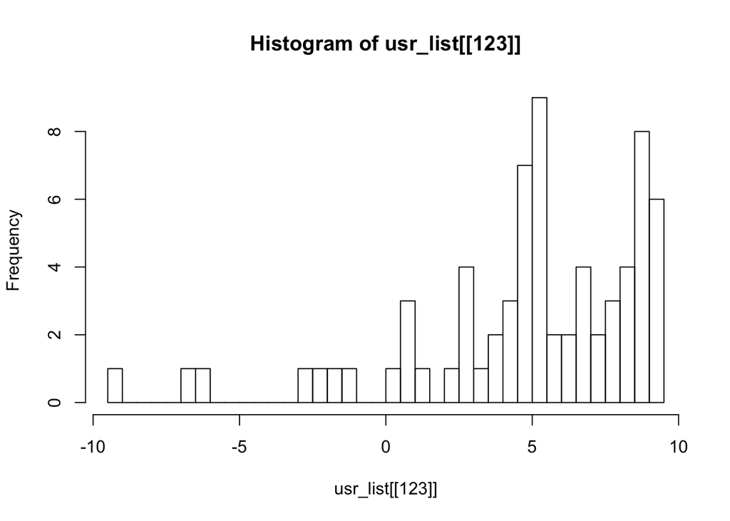

```r
usr_list <- as(Jester5k, "list")
hist(usr_list[[123]],breaks = 50)
```

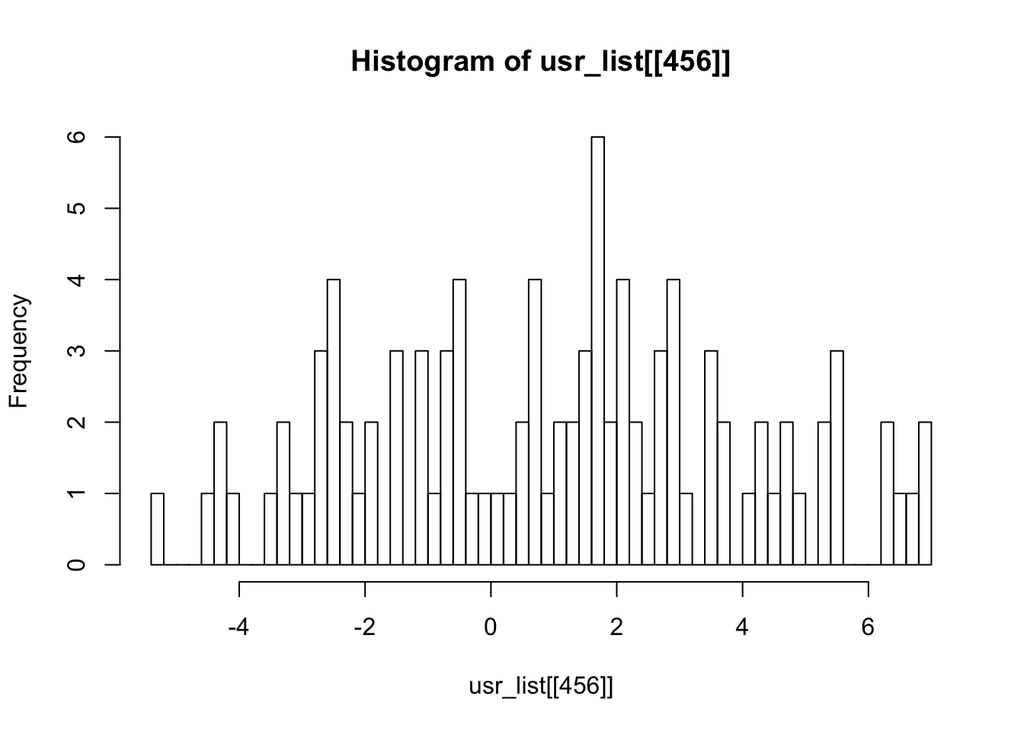

```r
hist(usr_list[[456]],breaks = 50)
```

```r
jester5k_norm <- normalize(Jester5k)
```

**Discuss:**

- Where are situations where this type of normalisation may breakdown? -How would we address these? Hint: KNN?

# Creating Training and Test sets

In recommenderlab the programming model is to create a validation scheme object that wraps the data. Below we define a k=5 fold Cross Validation scheme.

```r
validation_splits <- evaluationScheme(data = jester5k_norm,
                                      method = "cross-validation",
                                      train = 0.8,
                                      k = 5,
                                      goodRating = 5, #!Values >= this define of a successful recommendation.
                                      given = 3)
validation_splits
```

```
## Evaluation scheme with 3 items given
## Method: 'cross-validation' with 5 run(s).
## Good ratings: >=5.000000
## Data set: 5000 x 100 rating matrix of class 'realRatingMatrix' with 362106 ratings.
## Normalized using center on rows.
```

**Discuss:**

- Understanding the parameters here is important. Look at `help(evaluationScheme)` and consider:
  - What would be the effect of recommendation accuracy by pushing goodRating up or down?
  - Is it fair to compare classifiers with different `goodRating`?
  - What for with less than `given` recommendations how can we make recommendations?

# Generating recommendations

Here we examine two approaches to recommendations using the User-Based Collaborative Filtering approach (UBCF). We recommend users highly rated things from users with similar recommendation patterns.

## Predicting Ratings

The first approach is to predict ratings with a veiw to minimising the error.

```r
ratings_results <- evaluate(validation_splits, method="UBCF", type = "ratings")
```

```
## UBCF run fold/sample [model time/prediction time]
##   1
```

```
## [0.008sec/7.34sec]
##   2
```

```
## [0.002sec/6.847sec]
##   3
```

```
## [0.002sec/6.764sec]
##   4
```

```
## [0.003sec/6.717sec]
##   5
```

```
## [0.002sec/6.179sec]
```

```r
#look at resutls for cross validation folds
avg(ratings_results)
```

```
##         RMSE      MSE      MAE
## res 5.161409 26.64241 3.989138
```

**Discuss:** * Look at page 10 of the [recommenderlab vignette](https://cran.r-project.org/web/packages/recommenderlab/vignettes/recommenderlab.pdf) for a definition of the performance measures. * Do you think a model with this level of error useful in making joke recommendations?

## Predicting Top-N Lists

In this approach we want to provice the Top-N most likely recommendations. In terms of validation this model scores a ‘hit’ when a joke on the list was highly rated by the user. It scores a miss when the reverse is true.

Here we train a recommender for a series of Top-N lists, N = 1,3,5,10,15,20. Using these results we can build a ROC curve of the True Positive vs False Positive rates.

```r
topn_results <- evaluate(validation_splits, method="UBCF", type = "topNList", n=c(1,3,5,10,15,20))
```

```
## UBCF run fold/sample [model time/prediction time]
##   1
```

```
## [0.001sec/6.531sec]
##   2
```

```
## [0.002sec/6.685sec]
##   3
```

```
## [0.003sec/6.42sec]
##   4
```

```
## [0.002sec/6.673sec]
##   5
```

```
## [0.001sec/6.86sec]
```

```r
#look at resutls for cross validation folds
avg(topn_results)
```

```
##        TP      FP     FN      TN precision     recall        TPR
## 1  0.2360  0.7634 8.5972 87.4034 0.2361407 0.03221167 0.03221167
## 3  0.7012  2.2970 8.1320 85.8698 0.2338724 0.09253336 0.09253336
## 5  1.1284  3.8686 7.7048 84.2982 0.2258137 0.14750797 0.14750797
## 10 2.1132  7.8808 6.7200 80.2860 0.2114452 0.26774712 0.26774712
## 15 2.9420 12.0490 5.8912 76.1178 0.1962502 0.36772848 0.36772848
## 20 3.6410 16.3470 5.1922 71.8198 0.1821587 0.44956746 0.44956746
##            FPR
## 1  0.008532776
## 3  0.025706330
## 5  0.043312859
## 10 0.088340966
## 15 0.135272309
## 20 0.183732932
```

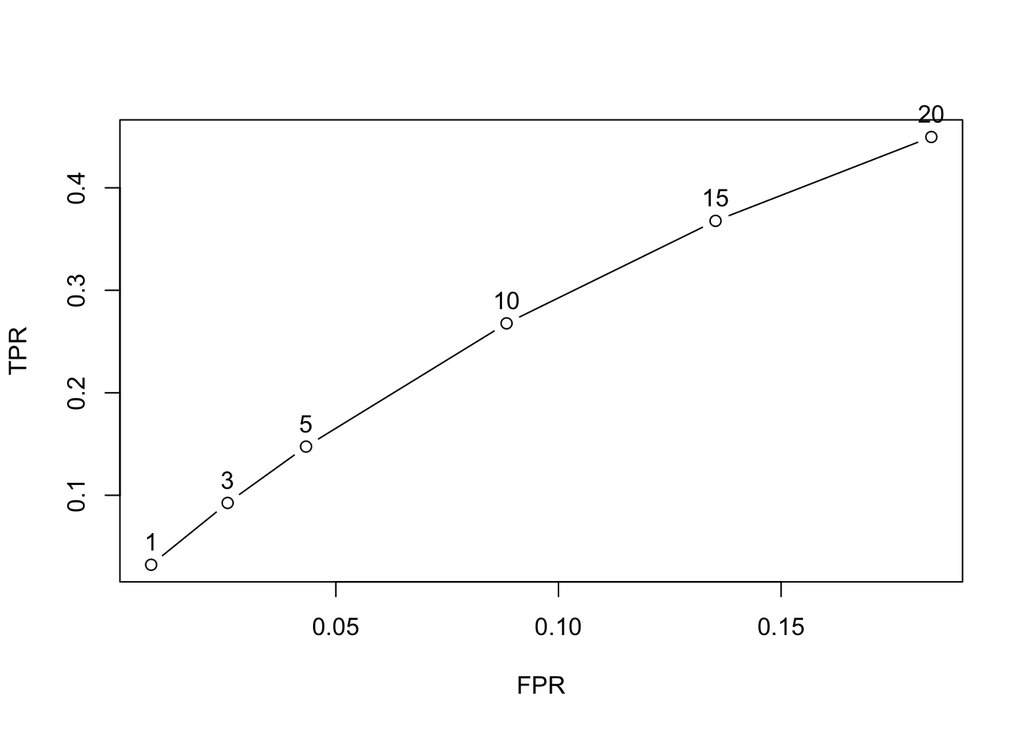

```r
#Plot a ROC curve
plot(topn_results, annotate=TRUE)
```

**Discuss:** * How do you rate this model’s performance at recommending jokes lists? - For small values of n? - For large values of n?

# Exercises

1. Experiment with varying the value of `given` What is the effect of increasing it on performance in both (TopN & rating) cases? Look at the help file, negative values are permitted.
2. Experiment with the different collaborative filtering methods available. Contrast the performance of UBCF with Item-Based Collaborative Filtering. Page 30 of he [recommenderlab vignette](https://cran.r-project.org/web/packages/recommenderlab/vignettes/recommenderlab.pdf) gives a handy way to compare multiple at once in a call to `evaluate()`.
3. What is the best combination of method and parameters?

# Extension

The [Book Crossing Dataset](http://www2.informatik.uni-freiburg.de/~cziegler/BX/) is book rating data set that contains some basic demographic information (Age, Location) which can be used to practice construction of a hybrid recommender system that uses content-based recommendation for users with low numbers of recommendations. You can get it as 3 tables in a .csv or an sql database. This would also be a great opportunity to practice some SQL to create the dataset!